# Final: Ice Cream

# Exploratory Data Analysis

#### For this project we will be addressing the question: Should Breyers introduce a new product of a flavor that would outperform their competitors, or improve an existing product to help boost their average rating?

We will explore the Ice Cream dataset by creating graphs, performing tests, and finding the measures of central tendency and variation. First, we’ll look at the overall dataset, and then the individual datasets of each of the four brands.

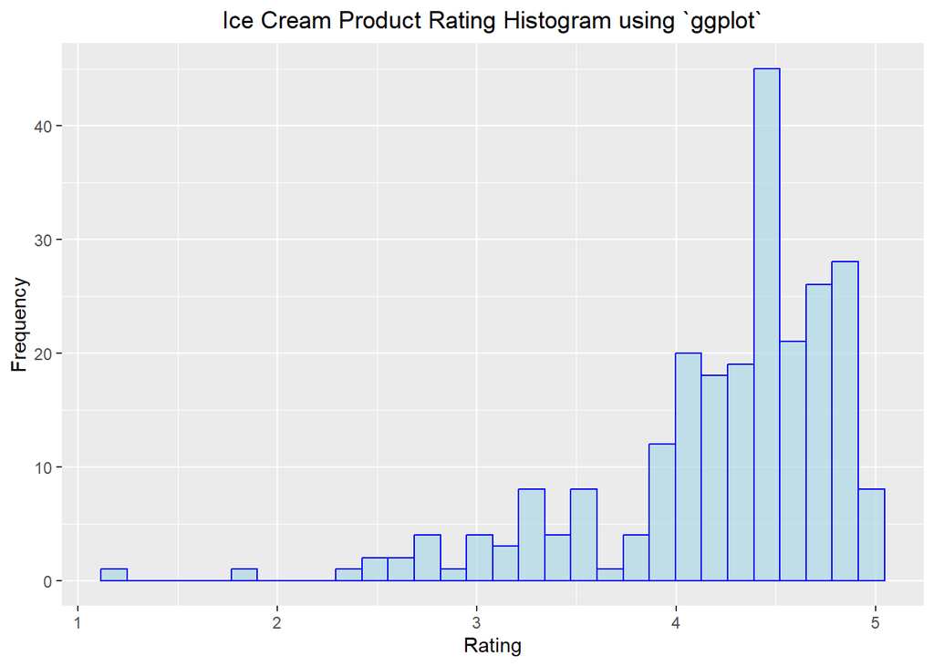

```r
library(ggplot2)
ggplot(data=products, aes(Rating)) +
  geom_histogram(col='blue', fill='lightblue', alpha=0.7) +
    labs(x="Rating", y="Frequency") +
    labs(title="Ice Cream Product Rating Histogram using `ggplot`") +
    theme(plot.title = element_text(hjust = 0.5))
```

This histogram shows the overall ratings of all ice-cream products across all 4 brands of ice-cream. We can see that there is a high frequency of ratings within the 4 - 5 star range. Based on the histogram above, we can see a left skewed distribution. To further test the skewness, we will perform a QQ plot.

```r
sd.ratings <- sd(products$Rating)
mean.ratings <- mean(products$Rating)
sd.ratings
mean.ratings
```

The mean of the data above is 4.223 and the standard deviation is 0.62

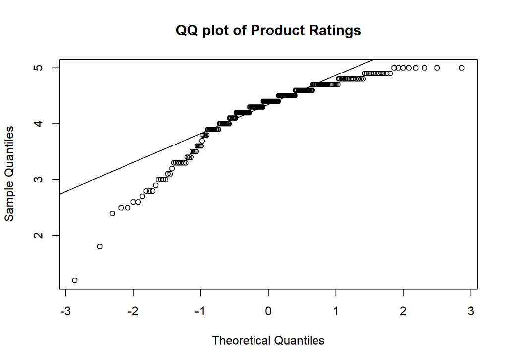

```r
qqnorm(products$Rating, main="QQ plot of Product Ratings")
qqline(products$Rating)
```

Based on the Q-Q plot above, we see that the graph is displaying a left skew as most of the data points are within the third to fifth sample quantile. Therefore this graph displays that the dataset does not present a normal distribution. To further test for normality, the Shapiro-Wilk test is conducted below.

```r
shapiro.test(products$Rating)
```

```
##
##  Shapiro-Wilk normality test
##
## data:  products$Rating
## W = 0.9, p-value = 9e-14
```

For the Shapiro-Wilk test, we are given the following hypotheses:

- `Null Hypothesis`: The sample comes from a normally distributed population
- `Alternative Hypothesis`: The sample does not come from a normally distributed population

Based on the results of the test, the p-value is less than the significance level of 0.05, which means that we reject the null hypothesis and conclude that the data from the sample does not come from a normally distributed population.

#### Measures of Central Tendency

With the combined dataset, we will calculate the mean, median, and mode for this dataset.

Based on these results, this further proves that the data is left skewed since the mean is the lowest value followed by the median and the the mode being the highest value.

#### Measures of Variation

With the combined dataset, we will calculate the range, mean deviation, standard deviation, and variance.

- `Range`: 1.2, 5
- `Mean Deviation`: 0.46
- `Standard Deviation`: 0.62
- `Variance`: 0.385

With the dataset, we are given data that ranges between 3.8 ratings points between the lowest rating and the highest rating. The mean deviation shows us that on average, each value in the dataset is about 0.46 away from the mean. The standard deviation shows us that the data is dispersed 0.62 points in relation to the mean. The variance shows that each data point is about 0.385 points away from the mean and other data points in the dataset.

```r
z4rating <- (4 - mean.ratings)/sd.ratings
```

We will generate a z-score for a rating of 4 in our distribution.

By taking the value of 4 and subtracting it with the mean 4.223 and dividing everything by the standard deviation of 0.62, we get the z score of -0.36.

Based on this result, we can determine that a rating of 4 lays within the range of the mean and one standard deviation to the left in our distribution.

```r
pnorm.rating <- pnorm(z4rating)
```

By taking the `pnorm()` function, 0.359 is the probability that a rating of `4` is under the distribution.

```r
loadPkg("Hmisc")
describe(products$Rating)
```

```
## products$Rating
##        n  missing distinct     Info     Mean      Gmd      .05      .10
##      241        0       29    0.995    4.223   0.6426      3.0      3.3
##      .25      .50      .75      .90      .95
##      4.0      4.4      4.7      4.8      4.9
##
## lowest : 1.2 1.8 2.4 2.5 2.6, highest: 4.6 4.7 4.8 4.9 5
```

Describing the overall data by using the the `describe()` function to highlight the ratings column.

### Breyers

Breyers is committed on using high quality ingredients. Breyers “start with high ingredients like colors and flavors from natural sources and sustainably farmed vanilla. [They] partner with American farmers for 100% Grade A milk and cream that comes from cows not treated with artificial growth hormones” (“About Breyers History”, n.d.).

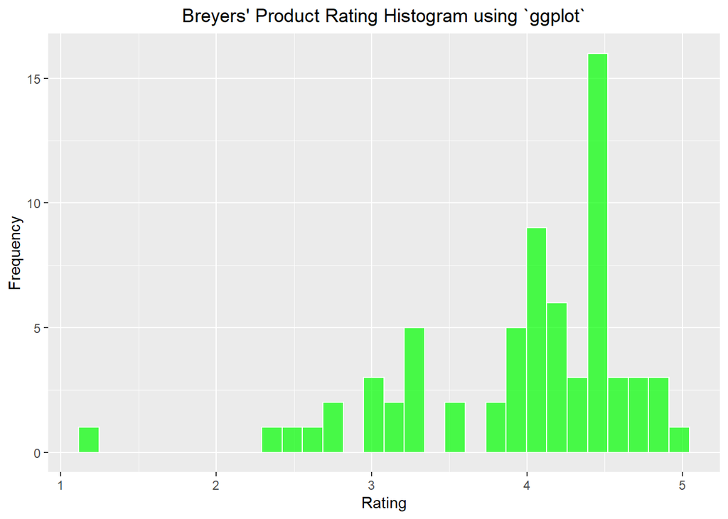

```r
breyers_data <- subset(products, Brand == "breyers")

breycol <- brandcolordf$color[brandcolordf$brand=="breyers"]
breyfill <-brandcolordf$fill[brandcolordf$brand=="breyers"]

ggplot(breyers_data, aes(Rating)) +
  geom_histogram(col=breycol, fill=breyfill, alpha=0.7) +
  labs(x="Rating", y="Frequency") +
  labs(title="Breyers' Product Rating Histogram using `ggplot`") +
  theme(plot.title = element_text(hjust = 0.5))
```

```r
mean.breyratings <- mean(breyers_data$Rating)
sd.breyratings <- sd(breyers_data$Rating)
```

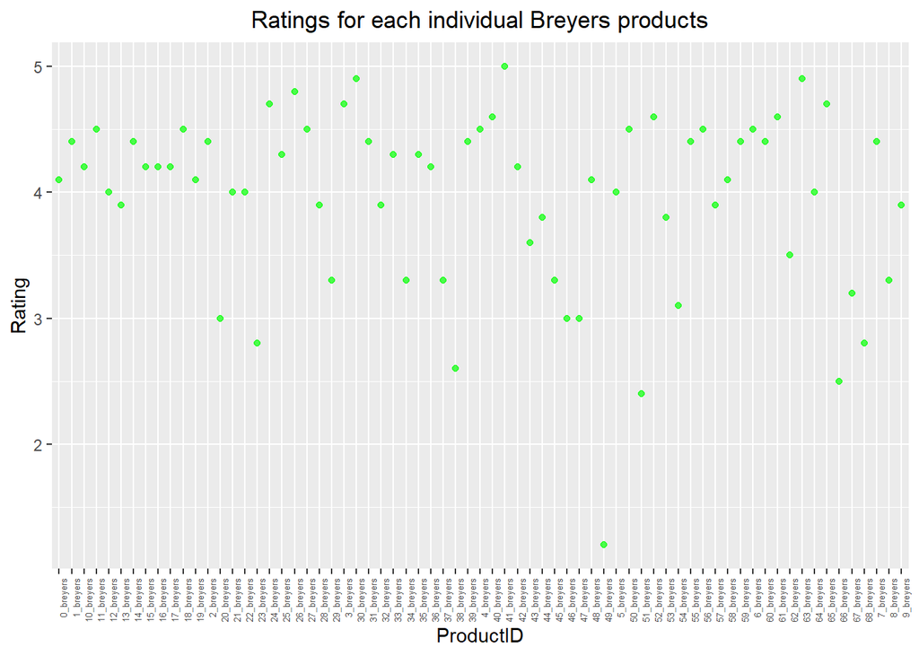

```r
#color and fill are inverted here for readability
ggplot(breyers_data, aes(x=ProductID, y=Rating)) +
  geom_point(col=breyfill, fill=breycol, alpha=0.7) +
  labs(x="ProductID", y='Rating') +
  labs(title="Ratings for each individual Breyers products") +
  theme(axis.text.x = element_text(angle=90, hjust=1, size = 5)) +
  theme(plot.title = element_text(hjust = 0.5))
```

```r
# Finding the highest rated products
max_rating_index <- which(breyers_data$Rating == max(breyers_data$Rating))
max_productname <- breyers_data$ProductName[max_rating_index]

# Finding the lowest rated products
min_rating_index <- which(breyers_data$Rating == min(breyers_data$Rating))
min_productname <- breyers_data$ProductName[min_rating_index]
```

Based from the graph, the highest rated Breyers product: OREO® Snack Cups 10ct

```
## [1] "Bought some of each flavor and stuck them in the freezer at work so anyone still in the office could have a treat with minimal communal handling. Lovely and Delicious."
## [2] "My favorite ice cream in portion sizes. Great idea. Please do mint chip."
```

Above are the two reviews of Breyers’ Oreo Snack Cups 10ct. Both reviews praise on how the ice cream is portioned out.

```
## [1] "Missed the flavor of s’more. No marshmallow flavor, chocolate very light- the graham crumb bites were good, overall very disappointed as this was really a splurge"
## [2] "Based on previous reviews, it seems a few didn't like it, but I personally did. It is actually one of my new favorite flavors so far. Have been trying to find a smores ice cream that was actually good since my favorite smores ice cream were discontinued by another company a few years ago. Ne…
## [3] "S’mores flavored is cream is one of my favorites. Brewers usually has great quality and therefore yummy ice cream so I was excited to see this flavor in the store. This version is very disappointing. The marshmallows are really gross-weird textures-almost like stale hard mini marshmallows yo…
## [4] "I was really looking forward to this ice cream but its actually gross. It tastes like really strong cinnamon and cardboard. :("
## [5] "I love ice cream and saw this at the store so I figured I would try S'mores along with the Peach cobbler. I tried the S'mores first, along with my family, and it was awful. taste nothing like S'mores. The graham cracker was grainy, marshmallows tasted like vanilla frosting. Will NOT buy agai…
## [6] "Marshmallows are chalky while the graham cracker piece does leave a lot to be desired. Please try again I would gladly give it another try when the contents are changed."
```

Above are the first 6 reviews of Breyers’ Layered Dessert S’mores. Customers complained on how the product does not taste like s’mores. Specifically, the marshmellows and graham crackers was either lacking or tasted awful, and the overall taste of what customers expected for s’mores did not meet their expectations. Though some customers actually like the product.

#### Measures of Central Tendency

With the Breyers data subset, we will calculate the mean, median, and mode for this dataset.

- `Mean`: 3.962
- `Median`: 4.2
- `Mode`: 4.4

The measures of central tendency show that the average rating is 3.962, the median rating is 4.2, with a score of 4.4 appearing most often. Again like the other brands, these values prove that the data displays a left skewed distribution.

#### Measures of Variation

With the Breyers data subset, we will calculate the range, mean deviation, standard deviation, and variance.

- `Range`: 1.2, 5
- `Mean Deviation`: 0.544
- `Standard Deviation`: 0.711
- `Variance`: 0.506

With the Breyers dataset, the data ranges 3.8 data points from the lowest point to the highest point. The mean deviation here shows us that on average, each value in the dataset is about 0.544 points away from the mean. The standard deviation shows us that the data is dispersed 0.711 points in relation to the mean. The variance shows that each data point is about 0.506 points away from the mean and other data points in the dataset.

## Addressing the issue

```r
summary_by_brand <- aggregate(Rating ~ Brand, data = products, FUN = summary)

summary_by_brand
```

```
##     Brand Rating.Min. Rating.1st Qu. Rating.Median Rating.Mean Rating.3rd Qu.
## 1      bj        1.80           4.10          4.60        4.33           4.70
## 2 breyers        1.20           3.60          4.20        3.96           4.40
## 3      hd        2.50           4.10          4.50        4.31           4.77
## 4 talenti        2.80           4.20          4.40        4.36           4.70
##   Rating.Max.
## 1        5.00
## 2        5.00
## 3        5.00
## 4        4.80
```

Here we see that the average rating for the Breyers brand is the lowest among the other brands in the dataset with an average rating of 3.96 compared to a rating of 4.00+ for the other brands.

### Comparative Analysis

Further statistical comparisons will be conducted to compare the four brands in order to gain information for further tests.

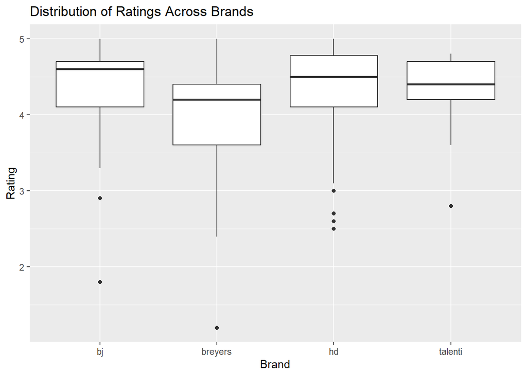

```r
ggplot(products, aes(x=Brand, y=Rating)) +
  geom_boxplot() +
  labs(title = "Distribution of Ratings Across Brands")
```

With the box plot above, we see the distribution of the ratings across the four brands ice cream. We see that the first and third quartiles and the median for Ben and Jerry’s, Häagen-Dazs, and Talenti all fall above the rating of 4 mark. Breyer’s first quartile falls below the rating of 4 line. Overall, we see that the Breyer’s data performs the worse compared to the other brands.

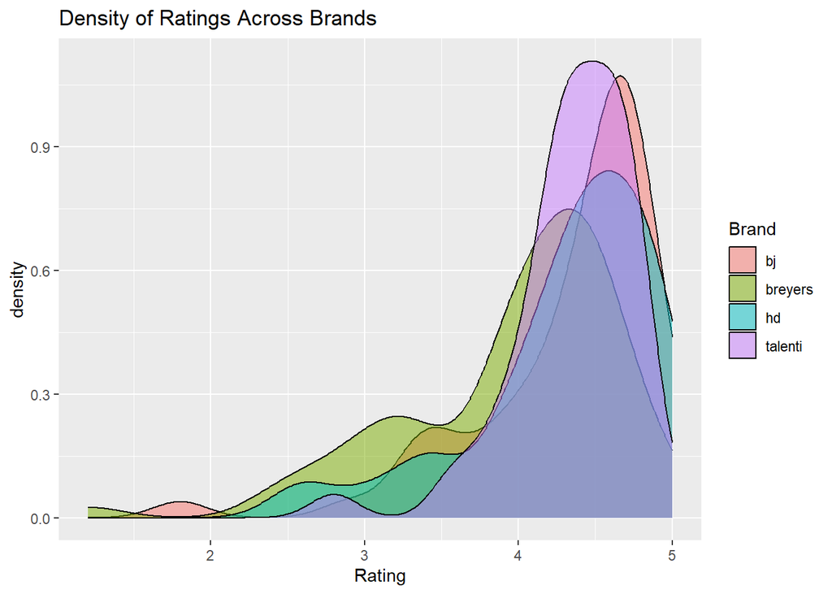

```r
ggplot(products, aes(x=Rating, fill=Brand)) +
  geom_density(alpha=0.5) +
  labs(title = "Density of Ratings Across Brands")
```

With the density plot above, we see the data in a continuous and smooth representation. We see that the density is heavily concentrated in the right side of the graph. Breyers still appear to be the shortest hill among the other brands at the rating of 4 area. The data also shows that Breyers produce a second hill around the 3 mark that is the tallest among the other brands.

Now, we will be determining if there is a significant difference between the means of Breyers and the other three brands individually through pairwise t-testing with a 0.05 significance level.

For these t-tests:

- `Null Hypothesis`: There is no significant difference between the means of Breyers and the other brand.
- `Alternative Hypothesis`: There is a significant difference between the means of Breyers and the other brand.

```r
breyers_ratings <- products$Rating[products$Brand == "breyers"]
bj_ratings <- products$Rating[products$Brand == "bj"]
hd_ratings <- products$Rating[products$Brand == "hd"]
talenti_ratings <- products$Rating[products$Brand == "talenti"]

t_test_bj <- t.test(breyers_ratings, bj_ratings)
t_test_hd <- t.test(breyers_ratings, hd_ratings)
t_test_tal <- t.test(breyers_ratings, talenti_ratings)

t_test_bj
```

```
##
##  Welch Two Sample t-test
##
## data:  breyers_ratings and bj_ratings
## t = -3, df = 124, p-value = 0.002
## alternative hypothesis: true difference in means is not equal to 0
## 95 percent confidence interval:
##  -0.600 -0.138
## sample estimates:
## mean of x mean of y
##      3.96      4.33
```

```r
t_test_hd
```

```
##
##  Welch Two Sample t-test
##
## data:  breyers_ratings and hd_ratings
## t = -3, df = 132, p-value = 0.002
## alternative hypothesis: true difference in means is not equal to 0
## 95 percent confidence interval:
##  -0.565 -0.124
## sample estimates:
## mean of x mean of y
##      3.96      4.31
```

```r
t_test_tal
```

```
##
##  Welch Two Sample t-test
##
## data:  breyers_ratings and talenti_ratings
## t = -4, df = 109, p-value = 2e-04
## alternative hypothesis: true difference in means is not equal to 0
## 95 percent confidence interval:
##  -0.598 -0.189
## sample estimates:
## mean of x mean of y
##      3.96      4.36
```

Based on the results of the t-tests, we see that all three p-values are less than the 0.05 significance level. Therefore, we will reject the null hypothesis and conclude that there is a significant difference between the means of Breyers and each of the three other brands.

For these tests:

- `Null Hypothesis`: There is no significant difference between the medians of Breyers and the other brand.
- `Alternative Hypothesis`: There is a significant difference between the medians of Breyers and the other brand.

```r
wilcox_test_bj <- wilcox.test(breyers_ratings, bj_ratings)
wilcox_test_hd <- wilcox.test(breyers_ratings, hd_ratings)
wilcox_test_tal <- wilcox.test(breyers_ratings, talenti_ratings)

wilcox_test_bj
```

```
##
##  Wilcoxon rank sum test with continuity correction
##
## data:  breyers_ratings and bj_ratings
## W = 1204, p-value = 2e-04
## alternative hypothesis: true location shift is not equal to 0
```

```r
wilcox_test_hd
```

```
##
##  Wilcoxon rank sum test with continuity correction
##
## data:  breyers_ratings and hd_ratings
## W = 1598, p-value = 6e-04
## alternative hypothesis: true location shift is not equal to 0
```

```r
wilcox_test_tal
```

```
##
##  Wilcoxon rank sum test with continuity correction
##
## data:  breyers_ratings and talenti_ratings
## W = 992, p-value = 0.001
## alternative hypothesis: true location shift is not equal to 0
```

Based on the results, we find that all p-values are less than the significance level of 0.05. Therefore, we will reject the null hypothesis and conclude that there is a significance difference between the medians of Breyers and the other three brands.

Next, we will be creating a linear regression model to allow us to make predictions on what Breyers should do to improve their ratings.

## Modeling

```r
lm_model <- lm(Rating ~ Brand + HAS_CARAMEL + HAS_CHOCOLATE + HAS_FRUIT + HAS_VANILLA + HAS_ORGANIC + IS_BAR, data = products)

summary(lm_model)
```

```
##
## Call:
## lm(formula = Rating ~ Brand + HAS_CARAMEL + HAS_CHOCOLATE + HAS_FRUIT +
##     HAS_VANILLA + HAS_ORGANIC + IS_BAR, data = products)
##
## Residuals:
##    Min     1Q Median     3Q    Max
## -2.607 -0.235  0.165  0.389  0.965
##
## Coefficients:
##                Estimate Std. Error t value Pr(>|t|)
## (Intercept)     4.41324    0.13031   33.87  < 2e-16 ***
## Brandbreyers   -0.49314    0.12256   -4.02  7.8e-05 ***
## Brandhd        -0.07259    0.11380   -0.64    0.524
## Brandtalenti    0.01082    0.12490    0.09    0.931
## HAS_CARAMEL1   -0.02464    0.13232   -0.19    0.852
## HAS_CHOCOLATE1  0.11482    0.09934    1.16    0.249
## HAS_FRUIT1     -0.00738    0.13491   -0.05    0.956
## HAS_VANILLA1   -0.22795    0.09285   -2.46    0.015 *
## HAS_ORGANIC1    0.29935    0.32143    0.93    0.353
## IS_BAR1         0.02204    0.14949    0.15    0.883
## ---
## Signif. codes:  0 '***' 0.001 '**' 0.01 '*' 0.05 '.' 0.1 ' ' 1
##
## Residual standard error: 0.6 on 231 degrees of freedom
## Multiple R-squared:  0.0996, Adjusted R-squared:  0.0646
## F-statistic: 2.84 on 9 and 231 DF,  p-value: 0.00344
```

Above we see how the linear regression model is structured.

```r
subset_data <- subset(products, Brand %in% c("bj", "hd", "talenti", "breyers") & Rating == 5)

ingredient_categories <- subset_data[, c("Brand", "ProductName", "Rating",  "HAS_CARAMEL", "HAS_CHOCOLATE", "HAS_FRUIT", "HAS_VANILLA", "HAS_ORGANIC", "IS_BAR")]

product_ingredients <- unique(ingredient_categories)

product_ingredients
```

```
##       Brand                                        ProductName Rating
## 8        bj                      Chocolate Peanut Butter Split      5
## 30       bj                                   Ice Cream Sammie      5
## 72       hd                      Chocolate Fudge Non-Dairy Bar      5
## 89       hd              Honey Salted Caramel Almond Ice Cream      5
## 101      hd                          Peppermint Bark Ice Cream      5
## 102      hd                      Peppermint Bark Ice Cream Bar      5
## 121      hd Vanilla Caramel White Chocolate TRIO CRISPY LAYERS      5
## 214 breyers                              OREO® Snack Cups 10ct      5
##     HAS_CARAMEL HAS_CHOCOLATE HAS_FRUIT HAS_VANILLA HAS_ORGANIC IS_BAR
## 8             0             1         1           1           0      0
## 30            0             1         0           1           0      0
## 72            0             1         0           1           0      1
## 89            0             0         0           1           0      0
## 101           0             1         0           0           0      0
## 102           0             1         0           1           0      1
## 121           1             1         0           1           0      0
## 214           0             1         0           0           0      0
```

Based on the table above, we see the products across all 4 brands that have an average rating of 5 with the ingredient categories that each have.

We will now predict the ratings of ice cream products that contains a different combination of ingredient categories to see which would result in a high rating.

The different ingredient categories are as follows:

- Has Caramel
- Has Chocolate
- Has Fruit
- Has Vanilla
- Has Organic Ingredients
- Is a Bar

```r
new_data <- data.frame(
  Brand = "breyers",
  Name = "Chocolate",
  HAS_CARAMEL = 0,
  HAS_CHOCOLATE = 1,
  HAS_FRUIT = 0,
  HAS_VANILLA = 0,
  HAS_ORGANIC = 0,
  IS_BAR = 0
)

new_data$HAS_CARAMEL <- as.factor(new_data$HAS_CARAMEL)
new_data$HAS_CHOCOLATE <- as.factor(new_data$HAS_CHOCOLATE)
new_data$HAS_FRUIT <- as.factor(new_data$HAS_FRUIT)
new_data$HAS_VANILLA <- as.factor(new_data$HAS_VANILLA)
new_data$HAS_ORGANIC <- as.factor(new_data$HAS_ORGANIC)
new_data$IS_BAR <- as.factor(new_data$IS_BAR)

predicted_ratings <- predict(lm_model, newdata = new_data)
predicted_ratings
```

```
##    1
## 4.03
```

If Breyers were to introduce a product that contains a chocolate ingredient by itself, the predicted rating for it would be 4.035. We see that having a product that contains chocolate is a good indicator for a good rating.

```r
new_data <- data.frame(
  Brand = "breyers",
  Name = "Vanilla",
  HAS_CARAMEL = 0,
  HAS_CHOCOLATE = 0,
  HAS_FRUIT = 0,
  HAS_VANILLA = 1,
  HAS_ORGANIC = 0,
  IS_BAR = 0
)

new_data$HAS_CARAMEL <- as.factor(new_data$HAS_CARAMEL)
new_data$HAS_CHOCOLATE <- as.factor(new_data$HAS_CHOCOLATE)
new_data$HAS_FRUIT <- as.factor(new_data$HAS_FRUIT)
new_data$HAS_VANILLA <- as.factor(new_data$HAS_VANILLA)
new_data$HAS_ORGANIC <- as.factor(new_data$HAS_ORGANIC)
new_data$IS_BAR <- as.factor(new_data$IS_BAR)

predicted_ratings <- predict(lm_model, newdata = new_data)
predicted_ratings
```

```
##    1
## 3.69
```

On the other hand, if Breyers were to introduce a new product that contains a vanilla ingredient by itself, the predicted rating for it would be 3.692. Comparing vanilla against chocolate, we see that vanilla performs the poorly in terms of predicted ratings.

```r
new_data <- data.frame(
  Brand = "breyers",
  Name = "Chocolate/Vanilla",
  HAS_CARAMEL = 0,
  HAS_CHOCOLATE = 1,
  HAS_FRUIT = 0,
  HAS_VANILLA = 1,
  HAS_ORGANIC = 0,
  IS_BAR = 0
)

new_data$HAS_CARAMEL <- as.factor(new_data$HAS_CARAMEL)
new_data$HAS_CHOCOLATE <- as.factor(new_data$HAS_CHOCOLATE)
new_data$HAS_FRUIT <- as.factor(new_data$HAS_FRUIT)
new_data$HAS_VANILLA <- as.factor(new_data$HAS_VANILLA)
new_data$HAS_ORGANIC <- as.factor(new_data$HAS_ORGANIC)
new_data$IS_BAR <- as.factor(new_data$IS_BAR)

predicted_ratings <- predict(lm_model, newdata = new_data)
predicted_ratings
```

```
##    1
## 3.81
```

If Breyers were to include both chocolate and vanilla ingredients into a new product, then the predicted rating would be 3.807. The result is not as good for ratings.

```r
new_data <- data.frame(
  Brand = "breyers",
  Name = "Chocolate with Caramel",
  HAS_CARAMEL = 1,
  HAS_CHOCOLATE = 1,
  HAS_FRUIT = 0,
  HAS_VANILLA = 0,
  HAS_ORGANIC = 0,
  IS_BAR = 0
)

new_data$HAS_CARAMEL <- as.factor(new_data$HAS_CARAMEL)
new_data$HAS_CHOCOLATE <- as.factor(new_data$HAS_CHOCOLATE)
new_data$HAS_FRUIT <- as.factor(new_data$HAS_FRUIT)
new_data$HAS_VANILLA <- as.factor(new_data$HAS_VANILLA)
new_data$HAS_ORGANIC <- as.factor(new_data$HAS_ORGANIC)
new_data$IS_BAR <- as.factor(new_data$IS_BAR)

predicted_ratings <- predict(lm_model, newdata = new_data)
predicted_ratings
```

```
##    1
## 4.01
```

If Breyers were to introduce a new product that contains caramel and chocolate, then the predicted rating would be 4.01.

```r
new_data <- data.frame(
  Brand = "breyers",
  Name = "Organic Chocolate",
  HAS_CARAMEL = 0,
  HAS_CHOCOLATE = 1,
  HAS_FRUIT = 0,
  HAS_VANILLA = 0,
  HAS_ORGANIC = 1,
  IS_BAR = 0
)

new_data$HAS_CARAMEL <- as.factor(new_data$HAS_CARAMEL)
new_data$HAS_CHOCOLATE <- as.factor(new_data$HAS_CHOCOLATE)
new_data$HAS_FRUIT <- as.factor(new_data$HAS_FRUIT)
new_data$HAS_VANILLA <- as.factor(new_data$HAS_VANILLA)
new_data$HAS_ORGANIC <- as.factor(new_data$HAS_ORGANIC)
new_data$IS_BAR <- as.factor(new_data$IS_BAR)

predicted_ratings <- predict(lm_model, newdata = new_data)
predicted_ratings
```

```
##    1
## 4.33
```

If Breyers were to introduce a new product that contains chocolate and organic ingredients, then the predicted rating would be 4.334.

```r
new_data <- data.frame(
  Brand = "breyers",
  Name = "Chocolate/Vanilla",
  HAS_CARAMEL = 0,
  HAS_CHOCOLATE = 1,
  HAS_FRUIT = 1,
  HAS_VANILLA = 0,
  HAS_ORGANIC = 1,
  IS_BAR = 1
)

new_data$HAS_CARAMEL <- as.factor(new_data$HAS_CARAMEL)
new_data$HAS_CHOCOLATE <- as.factor(new_data$HAS_CHOCOLATE)
new_data$HAS_FRUIT <- as.factor(new_data$HAS_FRUIT)
new_data$HAS_VANILLA <- as.factor(new_data$HAS_VANILLA)
new_data$HAS_ORGANIC <- as.factor(new_data$HAS_ORGANIC)
new_data$IS_BAR <- as.factor(new_data$IS_BAR)

predicted_ratings <- predict(lm_model, newdata = new_data)
predicted_ratings
```

```
##    1
## 4.35
```

```r
exact_match_products <- products[products$HAS_CHOCOLATE == 1 & products$HAS_FRUIT == 1 & products$HAS_ORGANIC == 1 & products$IS_BAR == 1, c("Brand", "ProductName", "Rating")]

exact_match_products
```

```
## [1] Brand       ProductName Rating
## <0 rows> (or 0-length row.names)
```

Lets try to dissect each category to find possible products to influence the new product or to improve Breyers’ existing products.

```r
test_match1 <- products[products$HAS_CHOCOLATE == 1 & products$HAS_FRUIT == 1, c("Brand", "ProductName", "Rating")]

test_match1
```

```
##       Brand                                        ProductName Rating
## 8        bj                      Chocolate Peanut Butter Split    5.0
## 15       bj                                     Cherry Garcia®    4.4
## 22       bj                                     Chunky Monkey®    4.4
## 52       bj                 Sweet Like Sugar Cookie Dough Core    4.8
## 58       hd        White Chocolate Raspberry Truffle Ice Cream    4.9
## 59       hd                Banana Peanut Butter Chip Ice Cream    4.7
## 93       hd Lemon Raspberry White Chocolate TRIO CRISPY LAYERS    4.3
## 127      hd            White Chocolate Raspberry Ice Cream Bar    3.9
## 129 talenti                              BANANA CARAMEL CRUNCH    4.2
## 131 talenti              BLACK RASPBERRY CHOCOLATE CHIP GELATO    4.0
## 132 talenti                    BLACK RASPBERRY VANILLA PARFAIT    4.5
## 136 talenti                        CHOCOLATE CHERRY CHEESECAKE    4.3
## 144 talenti                              DARK CHOCOLATE CHERRY    4.2
## 150 talenti                                    LEMON BERRY PIE    4.2
## 170 talenti                   VANILLA BLUEBERRY CRUMBLE GELATO    3.9
## 200 breyers            Raspberry Cheesecake Gelato Indulgences    4.5
## 228 breyers                          Black Raspberry Chocolate    4.4
```

```r
new_data <- data.frame(
  Brand = "breyers",
  Name = "Chocolate/Vanilla",
  HAS_CARAMEL = 0,
  HAS_CHOCOLATE = 1,
  HAS_FRUIT = 1,
  HAS_VANILLA = 0,
  HAS_ORGANIC = 0,
  IS_BAR = 0
)

new_data$HAS_CARAMEL <- as.factor(new_data$HAS_CARAMEL)
new_data$HAS_CHOCOLATE <- as.factor(new_data$HAS_CHOCOLATE)
new_data$HAS_FRUIT <- as.factor(new_data$HAS_FRUIT)
new_data$HAS_VANILLA <- as.factor(new_data$HAS_VANILLA)
new_data$HAS_ORGANIC <- as.factor(new_data$HAS_ORGANIC)
new_data$IS_BAR <- as.factor(new_data$IS_BAR)

predicted_ratings <- predict(lm_model, newdata = new_data)
```

Finding products that have chocolate and fruit ingredients, we see that there are 17 products, which two are Breyers products. To see if we can improve these products we need to consider the predicted rating for the improvement, which would be 4.028. Since the predicted rating is lower than the ratings of their existing products, it is best to not pursue changing the product.

```r
test_match2 <- products[products$HAS_CHOCOLATE == 1 & products$HAS_ORGANIC == 1, c("Brand", "ProductName", "Rating")]

test_match2
```

```
##       Brand                     ProductName Rating
## 156 talenti ORGANIC CHOCOLATE MOUSSE GELATO    4.3
```

Finding products that has chocolate and organic ingredients, we see that only result comes up from Talenti.

```r
test_match3 <- products[products$HAS_FRUIT == 1 & products$HAS_ORGANIC == 1, c("Brand", "ProductName", "Rating")]

test_match3
```

```
## [1] Brand       ProductName Rating
## <0 rows> (or 0-length row.names)
```

Finding products that has fruits and organic ingredients, we see that there are no products that contain these ingredient categories.

```r
test_match4 <- products[products$HAS_CHOCOLATE == 1 & products$HAS_FRUIT == 1 & products$IS_BAR == 1, c("Brand", "ProductName", "Rating")]

test_match4
```

```
##     Brand                             ProductName Rating
## 127    hd White Chocolate Raspberry Ice Cream Bar    3.9
```

Finding products that has chocolate and fruit ingredients that is also a bar, provides us one match from Häagen-Dazs.

```r
find_bars <- products[products$Brand == "breyers" & products$IS_BAR == 1, c("ProductName", "Rating")]

find_bars
```

```
##                      ProductName Rating
## 206        CarbSmart™ Almond Bar    4.3
## 209       CarbSmart™ Vanilla Bar    4.2
## 212         CarbSmart™ Fudge Bar    4.4
## 213    CarbSmart™ Mint Fudge Bar    4.6
## 238 CarbSmart™ Caramel Swirl Bar    4.7
```

The bars that Breyers currently offer is their CarbSmart products. According to Breyers’ website, their “CarbSmart products prove that fewer carbs [does] not mean less taste. … At 3-5g net carbs and 60-150 calories per serving, you can treat yourself to a scoop without the guilt” (“CarbSmart”, n.d.). Given the name of the product line, not everyone would be inclined to purchase the product since they are not in a low-carb diet. Even those that are purchasing from this product line love the products, Breyers should consider introducing regular-style bars.

## Introduction of a New Product: Ice Cream Bars

```r
highrated_choco_breyers <- subset(products, Brand == "breyers" & Rating >= 4.5 & HAS_CHOCOLATE == 1, select = c(ProductName, Rating))

highrated_choco_breyers
```

```
##                                 ProductName Rating
## 176                               Chocolate    4.7
## 179            Vanilla Chocolate Strawberry    4.5
## 191      Vanilla Caramel Gelato Indulgences    4.5
## 197                  Lactose Free Chocolate    4.7
## 199         Non-Dairy Vanilla Peanut Butter    4.8
## 200 Raspberry Cheesecake Gelato Indulgences    4.5
## 203            No Sugar Added Caramel Swirl    4.9
## 213               CarbSmart™ Mint Fudge Bar    4.6
## 214                   OREO® Snack Cups 10ct    5.0
## 223         Non-Dairy OREO® Cookies & Cream    4.5
## 225                       Vanilla Chocolate    4.6
## 229                       Chocolate Truffle    4.5
## 236               Chocolate Snack Cups 10ct    4.9
## 238            CarbSmart™ Caramel Swirl Bar    4.7
```

Bringing up the products that Breyers makes that has chocolate and is rated 4.5, we see the list above.

```r
highrated_fruit_breyers <- subset(products, Brand == "breyers" & Rating >= 4.5 & HAS_FRUIT == 1, select = c(ProductName, Rating))

highrated_fruit_breyers
```

```
##                                 ProductName Rating
## 200 Raspberry Cheesecake Gelato Indulgences    4.5
```

For Breyers products that contain fruit ingredients that have a rating of 4.5 and above, only one product comes up, Raspberry Cheesecake Gelato Indulgences.

```r
highrated_organic <- subset(products, Rating >= 4.0 & HAS_ORGANIC == 1, select = c(ProductName, Rating))

highrated_organic
```

```
##                         ProductName Rating
## 155    ORGANIC BROWN BUTTER CARAMEL    4.5
## 156 ORGANIC CHOCOLATE MOUSSE GELATO    4.3
## 157    ORGANIC GINGER MATCHA GELATO    4.7
## 158 ORGANIC OAK-AGED VANILLA GELATO    4.8
```

When it comes to organic ingredients, Breyers does not use any organic ingredients (at least listed in their ingredients). Therefore, we will check products from other brands that has organic ingredients and have a rating of 4.0 or more. From this we can see the products that Breyers can consider using the ingredients for their new product.

Based on the three categories, we can suggest that Breyers incorporates the product ingredients of the Products `Chocolate`, `Raspberry Cheesecake Gelato Indulgences`, and `Organic Chocolate Mousse Gelato`.

Let’s look at the ingredients used in Breyers’ Bar products

```r
breyers_products <- subset(products, Brand == "breyers" & IS_BAR == 1, select = c("ProductName", "Ingredients"))

breyers_products
```

```
##                      ProductName
## 206        CarbSmart™ Almond Bar
## 209       CarbSmart™ Vanilla Bar
## 212         CarbSmart™ Fudge Bar
## 213    CarbSmart™ Mint Fudge Bar
## 238 CarbSmart™ Caramel Swirl Bar
##                                                                                                                                                                                                                                                                                                          …
## 206                                                                                                                                  MILK, COCONUT OIL, WATER, MALTITOL SYRUP, SUGAR, ALMONDS, POLYDEXTROSE, SOYBEAN OIL, DUTCHED COCOA (PROCESSED WITH ALKALI), SODIUM CASEINATE, WHEY, GLYCERIN, CALCIU…
## 209                                                                                                                                           MILK, COCONUT OIL, WATER, MALTITOL SYRUP, SUGAR, POLYDEXTROSE, SOYBEAN OIL, DUTCHED COCOA (PROCESSED WITH ALKALI), SODIUM CASEINATE, WHEY, GLYCERIN, CALCIU…
## 212                                                                                                                                                                                                                        MILK, WATER, MALTITOL SYRUP, POLYDEXTROSE, COCONUT OIL, DUTCHED COCOA (PROCESS…
## 213                                                             MILK, WATER, FUDGE SWIRL, CORN SYRUP, HIGH FRUCTOSE CORN SYRUP, WATER, SUGAR, COCOA, MODIFIED FOOD STARCH (TAPIOCA), NATURAL FLAVOR, SALT, LACTIC ACID, POTASSIUM SORBATE (PRESERVATIVE), MALTITOL SYRUP, POLYDEXTROSE, COCONUT OIL, WHEY…
## 238 MILK, WATER, CARAMEL SWIRL, SUGAR, WATER, CORN SYRUP, HIGH FRUCTOSE CORN SYRUP, NONFAT MILK SOLIDS, BUTTER, CREAM, SALT, SALT, MOLASSES, PECTIN, SOY LECITHIN, NATURAL FLAVOR, POTASSIUM SORBATE (PRESERVATIVE), SODIUM CITRATE, LACTIC ACID, MALTITOL SYRUP, POLYDEXTROSE, COCONUT OIL, WHEY, GLYCER…
```

We see the Breyers’ bar products and its ingredients. Lets see the frequencies of each ingredient in these 5 products.

```r
#install.packages("tm")
library(tm)

multi_word_ingredients <- c("coconut oil", "maltitol syrup", "soybean oil", "dutched cocoa", "sodium caseinate", "calcium carbonate", "soluble corn fiber", "natural flavor", "vegetable gums", "carob bean", "soy lecithin", "mono and diglycerides", "acesulfame potassium", "fudge swirl", "corn syrup", "high fructose corn syrup", "lactic acid", "potassium sorbate", "carob bean gum", "guar gum", "color added", "caramel swirl", "nonfat milk solids", "sodium citrate", "modified food starch")
```

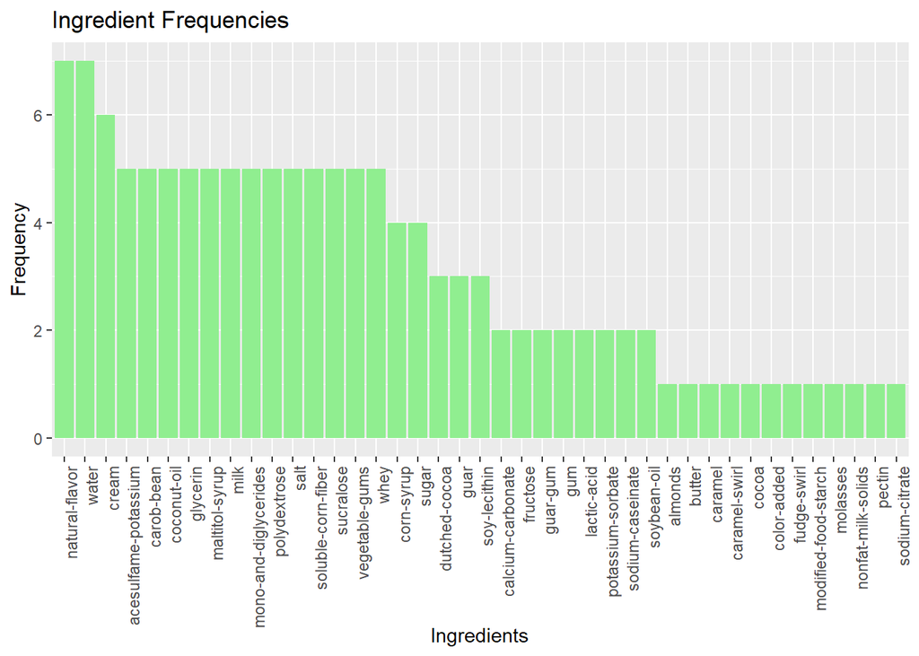

```r
products <- products %>% mutate_if(is.character, utf8::utf8_encode)

preprocess_text <- function(text) {
  text <- tolower(text)

  text <- gsub("[[:punct:]]", " ", text)

  text <- gsub("\\b\\d+\\b", "", text)

  text <- gsub("\\s+", " ", text)

  for (ingredient in multi_word_ingredients) {
    text <- gsub(ingredient, gsub(" ", "-", ingredient), text)
  }

  return(text)
}

bar_ingredients <- subset(products, Brand == "breyers" & IS_BAR == 1, select = c("Ingredients"))

bar_ingredients$Ingredients <- lapply(bar_ingredients$Ingredients, preprocess_text)

all_ingredients <- paste(bar_ingredients$Ingredients, collapse = " ")

tokenized_ingredients <- unlist(strsplit(all_ingredients, "\\s+"))

exclude_words <- c("with", "high", "processed", "alkali", "tapioca", "preservative", "for", "color")

tokenized_ingredients <- tokenized_ingredients[!tokenized_ingredients %in% exclude_words]

ingredient_freq <- table(tokenized_ingredients)

ingredient_freq_df <- data.frame(ingredient = names(ingredient_freq), frequency = as.numeric(ingredient_freq))

ingredient_freq_df <- ingredient_freq_df[order(ingredient_freq_df$frequency, decreasing = TRUE), ]
row.names(ingredient_freq_df) <- NULL

ggplot(ingredient_freq_df, aes(x = reorder(ingredient, -frequency), y = frequency)) +
  geom_bar(stat = "identity", fill = "lightgreen") +
  theme(axis.text.x = element_text(angle = 90, hjust = 1)) +
  labs(x = "Ingredients", y = "Frequency", title = "Ingredient Frequencies")
```

We see the frequencies of each ingredient from Breyers’ bar products. We will take this into consideration when deciding what ingredients to consider for the new product.

```r
product_ids <- c("3_breyers", "27_breyers", "28_talenti")
product_subset <- subset(products, ProductID %in% product_ids, select = c("ProductName", "Ingredients"))

product_subset
```

```
##                                 ProductName
## 156         ORGANIC CHOCOLATE MOUSSE GELATO
## 176                               Chocolate
## 200 Raspberry Cheesecake Gelato Indulgences
##                                                                                                                                                                                                                                                                                                          …
## 156                                                                                                                                                                              ORGANIC SKIM MILK, ORGANIC CANE SUGAR, ORGANIC CREAM, ORGANIC MILK, ORGANIC EGG WHITES AND EGG YOLKS, ORGANIC DEXTROSE, …
## 176                                                                                                                                                                                                                                                                                                      …
## 200 MILK, SUGAR, CORN SYRUP, WATER, COCONUT OIL, DEXTROSE, CREAM CHEESE, PASTEURIZED MILK, CREAM, CHEESE CULTURES, SALT, CAROB BEAN GUM, WHEY, RASPBERRY PUREE CONCENTRATE, DRIED CANE SYRUP, WHEAT FLOUR, BROWN SUGAR, VEGETABLE GUMS, CAROB BEAN GUM, GUAR GUM, MONO AND DIGLYCERIDES, NATURAL FLAVOR, …
```

Here we can see the ingredients of the three products that Breyers should consider when creating the new product.

Altogether, we can suggest that Breyers create the product `Organic Chocolate Raspberry Bar` to help improve their ratings. This product should the following ingredients:

- `Organic Milk`
- `Coconut Oil`
- `Water`
- `Organic Cream`
- `Organic Cane Sugar`
- `Organic Chocolate`
- `Natural Flavor`
- `Organic Dextrose`
- `Organic Butter`
- `Raspberry Puree Concentrate`
- `Organic Carob Bean Gum`
- `Mono and Diglycerides`
- `Whey`
- `Salt`

Here are ingredients that were considered after analyzing the ingredients of the other products. This is not a complete exhaustive list of ingredients to be used, but should be considered in order to achieve the ratings predicted by our model. More or less ingredients can be used, to make product taste up to their standards.

# References

About Breyers History. (N.d.). Breyers. Retrieved March 12, 2024, from https://www.breyers.com/us/en/about.html

CarbSmart. (N.d). Breyers. Retrieved April 15, 2024, from https://www.breyers.com/us/en/products/carbsmart.html

Pond, T. (2020, Sept). Ice Cream Dataset. Kaggle. Retrieved March 11, 2024, from https://www.kaggle.com/datasets/tysonpo/ice-cream-dataset/data

# References

About Breyers History. (N.d.). Breyers. Retrieved March 12, 2024, from https://www.breyers.com/us/en/about.html

About Us. (N.d.). Häagen Dazs. Retrieved March 12, 2024, from https://www.icecream.com/us/en/brands/haagen-dazs/about

Our Process. (N.d.). Talenti. Retrieved March 12, 2024, from https://www.talentigelato.com/us/en/our-process.html

Our Values, Activism, and Mission. (N.d.). Ben & Jerry’s. Retrieved March 12, 2024, from https://www.benjerry.com/values

Pond, T. (2020, Sept). Ice Cream Dataset. Kaggle. Retrieved March 11, 2024, from https://www.kaggle.com/datasets/tysonpo/ice-cream-dataset/data

Toledo, D. (2019, July 15). Cooking with machine learning: Dimension reduction. Medium. https://towardsdatascience.com/cooking-recipes-with-pca-5c33a4acb7db

#https://stackoverflow.com/questions/40795141/pca-for-categorical-features #https://www.gastonsanchez.com/visually-enforced/how-to/2012/10/13/MCA-in-R/ #https://medium.com/codex/dimensionality-reduction-techniques-for-categorical-continuous-data-75d2bca53100 #http://www.sthda.com/english/articles/31-principal-component-methods-in-r-practical-guide/114-mca-multiple-correspondence-analysis-in-r-essentials/